# IE360HW2

Halis Oguz

2022-05-11

```r
knitr::opts_chunk$set(echo = TRUE)
```

#Introduction This is a study of regression on a real data set in order to predict the unleaded gasoline sales for the upcoming 4 periods. The abbreviations for the variable names of the data set are present below. The study aims to investigate the relationship between the independent variables and the target variable so that a prediction model could be formed.

UGS: Unleaded gasoline sale in a given quarter(output variable),  
RNUV: An index indicating the rate of new unleaded gasoline using vehicles being added to the traffic in a quarter,  
PU: Average price (adjusted with an index) of a liter of unleaded gasoline in a quarter,  
PG: Average price (adjusted with an index) of a liter of diesel gasoline in a quarter,  
NUGV: Number of unleaded gasoline using vehicles in the traffic,  
NDGV: Number of diesel gasoline using vehicles in the traffic (per 1000 people),  
GNPA: Agriculture component of Gross National Product (adjusted with an index),  
GNPC: Commerce component of Gross National Product (adjusted with an index),  
GNP: Grand total for GNP (agriculture, commerce and other components total).

```r
options(repos="https://cran.rstudio.com" )
install.packages("zoo", repos = "https://cran.rstudio.com")
install.packages("gglpot2", repos = "https://cran.rstudio.com")
```

```r
install.packages("corrplot", repos = "https://cran.rstudio.com")
```

```
##
##   There is a binary version available but the source version is later:
##          binary source needs_compilation
## corrplot   0.89   0.92             FALSE
```

```
## installing the source package 'corrplot'
```

```r
library(zoo)
```

```r
library(ggplot2)
install.packages("ggcorrplot", repos = "https://cran.rstudio.com")
library(ggcorrplot)
library(corrplot)
install.packages("forecast", repos = "https://cran.rstudio.com")
library(forecast)
getwd()
```

```
## [1] "/Users/halis/Desktop"
```

```r
setwd("/Users/halis/Desktop")
data <- read.csv("IE360_Spring22_HW2_data.csv")
data
```

```
##    Quarter Unleaded.Gasoline.Sale..UGS.   RNUV X..LPG.Vehicles..NLPG.
## 1  2000_Q1                    1 128 971 0.0146                940 000
## 2  2000_Q2                    1 199 569 0.0205                941 000
## 3  2000_Q3                    1 370 167 0.0207                943 500
## 4  2000_Q4                    1 127 548 0.0163                948 000
## 5  2001_Q1                    1 033 918 0.0071                950 000
## 6  2001_Q2                    1 019 754 0.0051                955 000
## 7  2001_Q3                    1 209 916 0.0041                967 500
## 8  2001_Q4                    1 002 789 0.0048                990 000
## 9  2002_Q1                      893 722 0.0012              1 000 000
## 10 2002_Q2                    1 027 252 0.0032              1 001 000
## 11 2002_Q3                    1 153 265 0.0034              1 003 500
## 12 2002_Q4                      991 981 0.0044              1 008 000
## 13 2003_Q1                      806 257 0.0019              1 010 000
## 14 2003_Q2                      960 556 0.0056              1 048 000
```

[output cut: 117 more lines]

```r
str(data)
```

```
## 'data.frame':    32 obs. of  11 variables:
##  $ Quarter                              : chr  "2000_Q1" "2000_Q2" "2000_Q3" "2000_Q4" ...
##  $ Unleaded.Gasoline.Sale..UGS.         : chr  "1 128 971" "1 199 569" "1 370 167" "1 127 548" ...
##  $ RNUV                                 : num  0.0146 0.0205 0.0207 0.0163 0.0071 0.0051 0.0041 0.0048 0.0012 0.0032 ...
##  $ X..LPG.Vehicles..NLPG.               : chr  " 940 000" " 941 000" " 943 500" " 948 000" ...
##  $ Price.of.Unleaded.Gasoline..PU.      : num  469 459 440 402 412 ...
##  $ Price.of.Diesel.Gasoline..PG.        : num  356 345 327 301 306 ...
##  $ X..Unleaded.Gasoline.Vehicles..NUGV. : chr  "4 647 500" "4 742 876" "4 840 931" "4 919 685" ...
##  $ X..of.Diesel.Gasoline.Vehicles..NDGV.: num  282 284 287 288 288 ...
##  $ GNP.Agriculture                      : chr  "1 040 173" "1 760 460" "6 974 808" "3 267 125" ...
##  $ GNP.Commerce                         : chr  "3 483 132" "4 525 451" "5 915 204" "4 929 778" ...
##  $ GNP.Total                            : chr  "18 022 686" "21 797 130" "30 050 207" "24 480 153" ...
```

```r
summary(data)
```

```
##    Quarter          Unleaded.Gasoline.Sale..UGS.      RNUV
##  Length:32          Length:32                    Min.   :0.001200
##  Class :character   Class :character             1st Qu.:0.004100
##  Mode  :character   Mode  :character             Median :0.007250
##                                                  Mean   :0.008906
##                                                  3rd Qu.:0.013150
##                                                  Max.   :0.020700
##  X..LPG.Vehicles..NLPG. Price.of.Unleaded.Gasoline..PU.
##  Length:32              Min.   :402.1
##  Class :character       1st Qu.:479.2
##  Mode  :character       Median :526.7
##                         Mean   :519.2
##                         3rd Qu.:565.2
##                         Max.   :609.0
##  Price.of.Diesel.Gasoline..PG. X..Unleaded.Gasoline.Vehicles..NUGV.
##  Min.   :300.7                 Length:32
##  1st Qu.:366.9                 Class :character
##  Median :401.6                 Mode  :character
##  Mean   :400.4
##  3rd Qu.:449.2
##  Max.   :471.9
##  X..of.Diesel.Gasoline.Vehicles..NDGV. GNP.Agriculture    GNP.Commerce
##  Min.   :282.0                         Length:32          Length:32
##  1st Qu.:286.6                         Class :character   Class :character
##  Median :291.9                         Mode  :character   Mode  :character
##  Mean   :304.9
##  3rd Qu.:322.9
##  Max.   :357.3
##   GNP.Total
##  Length:32
##  Class :character
##  Mode  :character
##
##
##
```

#Analyzing the data When the csv document is transferred to the data object, it has been observed that there are several variables such as the target variable(shown above as Unleaded.Gasoline.Sale..UGS.) that have chr type. The variable is a numeric variable therefore it must be converted to numeric format within the other variables that require the same change.

```r
for(i in 1:32){
  for(j in 2:11)
  data[i,j] <- as.numeric(gsub(" ","",data[i,j]))
}

for(i in 2:11){
  data[,i] <- as.numeric(data[,i])
}
str(data)
```

```
## 'data.frame':    32 obs. of  11 variables:
##  $ Quarter                              : chr  "2000_Q1" "2000_Q2" "2000_Q3" "2000_Q4" ...
##  $ Unleaded.Gasoline.Sale..UGS.         : num  1128971 1199569 1370167 1127548 1033918 ...
##  $ RNUV                                 : num  0.0146 0.0205 0.0207 0.0163 0.0071 0.0051 0.0041 0.0048 0.0012 0.0032 ...
##  $ X..LPG.Vehicles..NLPG.               : num  940000 941000 943500 948000 950000 ...
##  $ Price.of.Unleaded.Gasoline..PU.      : num  469 459 440 402 412 ...
##  $ Price.of.Diesel.Gasoline..PG.        : num  356 345 327 301 306 ...
##  $ X..Unleaded.Gasoline.Vehicles..NUGV. : num  4647500 4742876 4840931 4919685 4954754 ...
##  $ X..of.Diesel.Gasoline.Vehicles..NDGV.: num  282 284 287 288 288 ...
##  $ GNP.Agriculture                      : num  1040173 1760460 6974808 3267125 1004528 ...
##  $ GNP.Commerce                         : num  3483132 4525451 5915204 4929778 3418387 ...
##  $ GNP.Total                            : num  18022686 21797130 30050207 24480153 15832648 ...
```

```r
data[,1] <- as.yearqtr(data$Quarter, format = "%Y_Q%q")
target_data <- data[,2]
target_data <- target_data[!is.na(target_data)]
target_data
```

```
##  [1] 1128971 1199569 1370167 1127548 1033918 1019754 1209916 1002789  893722
## [10] 1027252 1153265  991981  806257  960556 1104825  934022  832350  975165
## [19] 1094823  854517  762559  890693 1040946  793399  736580  877614  946783
## [28]  872000
```

#Converting the data into a useable format The data has been converted into numerical format in order to use the time series function.

```r
dataTS <- ts(target_data ,freq=4,start=c(2000,1))
str(dataTS)
```

```
##  Time-Series [1:28] from 2000 to 2007: 1128971 1199569 1370167 1127548 1033918 ...
```

```r
dataTS
```

```
##         Qtr1    Qtr2    Qtr3    Qtr4
## 2000 1128971 1199569 1370167 1127548
## 2001 1033918 1019754 1209916 1002789
## 2002  893722 1027252 1153265  991981
## 2003  806257  960556 1104825  934022
## 2004  832350  975165 1094823  854517
## 2005  762559  890693 1040946  793399
## 2006  736580  877614  946783  872000
```

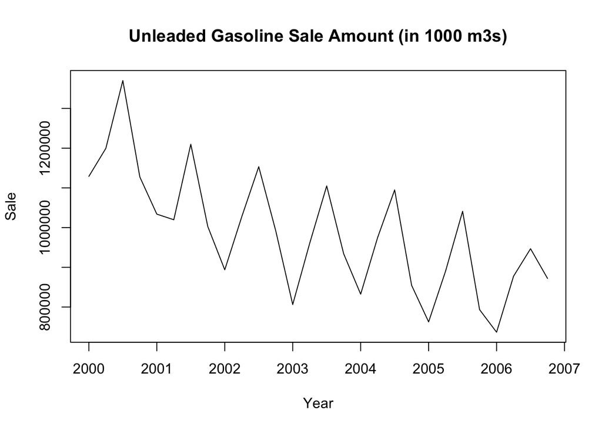

```r
ts.plot(dataTS,xlab = "Year", ylab = "Sale",main="Unleaded Gasoline Sale Amount (in 1000 m3s)")
```

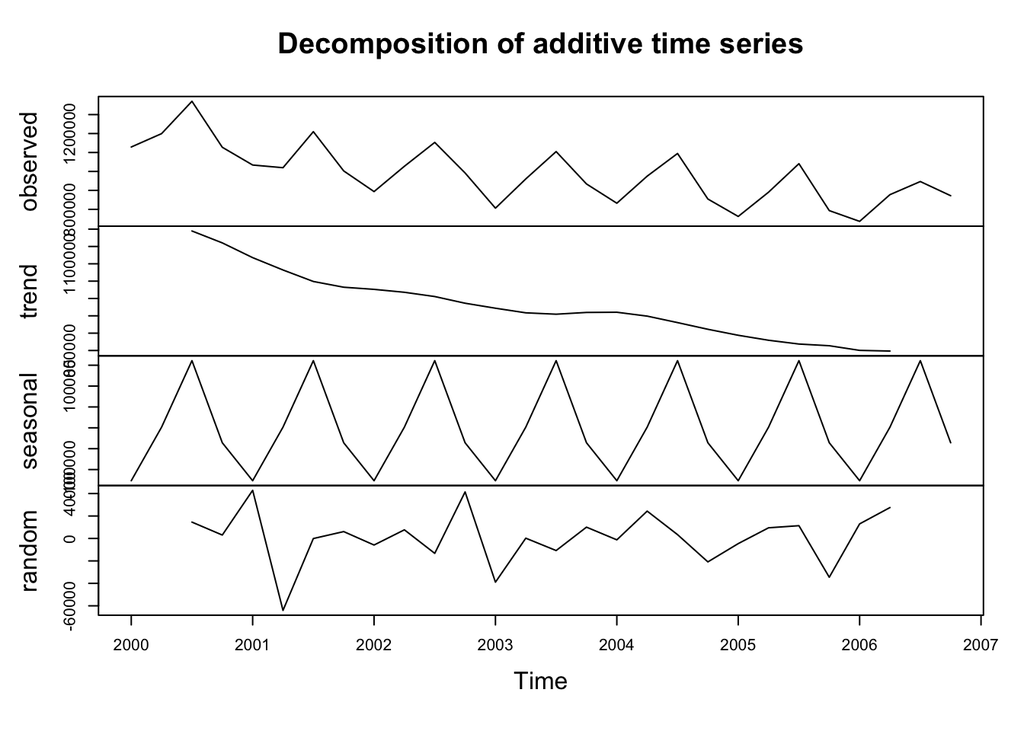

```r
decomposed <- decompose(dataTS, type="additive")
plot(decomposed)
```

In the previous plot the decomposition of the time series on trend and seasonal variables are shown clearly.

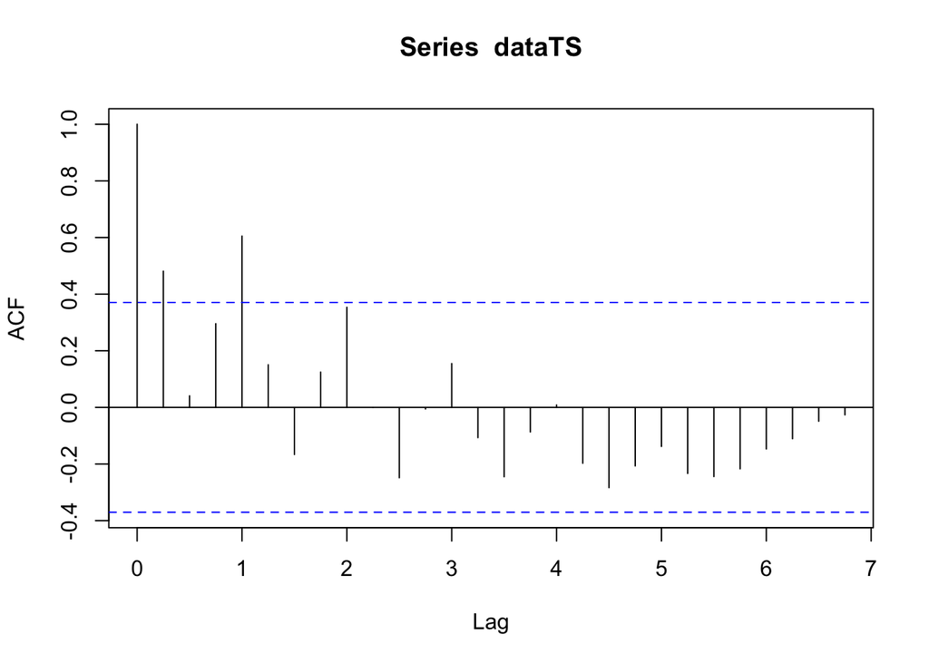

```r
acf(dataTS, lag = 28)
```

```r
trend <- 1:32
data$trend <- trend
data$quarter <- rep(1:4,8)
data$lag1 <- NA
data$lag4 <- NA
data$quarter <- as.factor(data$quarter)
```

##Adding some columns to the data set The data set has been provided with the trend and seasonality columns to find a coefficient corresponding to these components. Also, the quarter variable has been transformed to factor type since it is not a numeric variable. It has also been seen that the acf of lag 1 and lag 4 variables seem to be significant. Therefore, they are added on the data set to be added into the model.

```r
for(i in 1:28){
  data$lag1[i+1] = data$Unleaded.Gasoline.Sale..UGS.[i]
}
for(i in 1:28){
  data$lag4[i+4] = data$Unleaded.Gasoline.Sale..UGS.[i]
}

data
```

```
##    Quarter Unleaded.Gasoline.Sale..UGS.   RNUV X..LPG.Vehicles..NLPG.
## 1  2000 Q1                      1128971 0.0146                 940000
## 2  2000 Q2                      1199569 0.0205                 941000
## 3  2000 Q3                      1370167 0.0207                 943500
## 4  2000 Q4                      1127548 0.0163                 948000
## 5  2001 Q1                      1033918 0.0071                 950000
## 6  2001 Q2                      1019754 0.0051                 955000
## 7  2001 Q3                      1209916 0.0041                 967500
## 8  2001 Q4                      1002789 0.0048                 990000
## 9  2002 Q1                       893722 0.0012                1000000
## 10 2002 Q2                      1027252 0.0032                1001000
## 11 2002 Q3                      1153265 0.0034                1003500
## 12 2002 Q4                       991981 0.0044                1008000
## 13 2003 Q1                       806257 0.0019                1010000
## 14 2003 Q2                       960556 0.0056                1048000
```

[output cut: 117 more lines]

```r
model1 <- lm(Unleaded.Gasoline.Sale..UGS. ~. - Quarter, data = data[1:28,])
summary(model1)
```

```
##
## Call:
## lm(formula = Unleaded.Gasoline.Sale..UGS. ~ . - Quarter, data = data[1:28,
##     ])
##
## Residuals:
##    Min     1Q Median     3Q    Max
## -38364  -9454   -409   7421  33438
##
## Coefficients:
##                                         Estimate Std. Error t value Pr(>|t|)
## (Intercept)                            4.986e+06  2.057e+06   2.424   0.0416 *
## RNUV                                   3.504e+06  3.001e+06   1.168   0.2766
## X..LPG.Vehicles..NLPG.                -5.564e-01  2.999e-01  -1.855   0.1007
## Price.of.Unleaded.Gasoline..PU.        8.635e+02  1.604e+03   0.538   0.6049
## Price.of.Diesel.Gasoline..PG.         -2.634e+03  2.381e+03  -1.106   0.3008
## X..Unleaded.Gasoline.Vehicles..NUGV.  -1.521e+00  8.887e-01  -1.712   0.1253
## X..of.Diesel.Gasoline.Vehicles..NDGV.  1.718e+04  9.680e+03   1.775   0.1139
## GNP.Agriculture                       -4.690e-02  6.735e-02  -0.696   0.5059
## GNP.Commerce                           1.273e-01  1.153e-01   1.104   0.3016
## GNP.Total                             -1.510e-02  2.391e-02  -0.631   0.5454
## trend                                  2.338e+04  2.579e+04   0.907   0.3911
## quarter2                               3.018e+04  1.048e+05   0.288   0.7807
## quarter3                               4.411e+05  4.018e+05   1.098   0.3042
## quarter4                               1.900e+05  1.179e+05   1.611   0.1458
## lag1                                  -5.164e-01  3.120e-01  -1.655   0.1364
## lag4                                  -8.342e-02  2.660e-01  -0.314   0.7618
## ---
## Signif. codes:  0 '***' 0.001 '**' 0.01 '*' 0.05 '.' 0.1 ' ' 1
##
## Residual standard error: 29960 on 8 degrees of freedom
##   (4 observations deleted due to missingness)
## Multiple R-squared:  0.9796, Adjusted R-squared:  0.9414
## F-statistic: 25.63 on 15 and 8 DF,  p-value: 4.113e-05
```

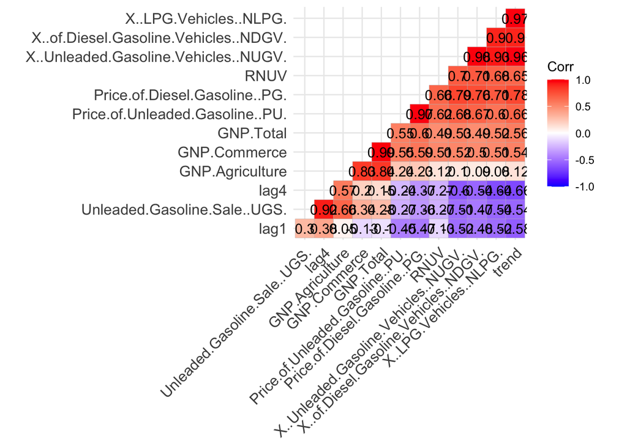

```r
new_data <- data[!is.na(data$Unleaded.Gasoline.Sale..UGS. & data$lag1 & data$lag4),]

corr = cor(new_data[,unlist(lapply(new_data, is.numeric))])

ggcorrplot(corr,
           hc.order = TRUE,
           type='lower',
           lab=TRUE)
```

```r
model2 <- lm(Unleaded.Gasoline.Sale..UGS. ~. - Quarter - Price.of.Diesel.Gasoline..PG.
             - GNP.Agriculture, data = data[1:28,])
summary(model2)
```

```
##
## Call:
## lm(formula = Unleaded.Gasoline.Sale..UGS. ~ . - Quarter - Price.of.Diesel.Gasoline..PG. -
##     GNP.Agriculture, data = data[1:28, ])
##
## Residuals:
##    Min     1Q Median     3Q    Max
## -44943  -8950   -644  11340  36871
##
## Coefficients:
##                                         Estimate Std. Error t value Pr(>|t|)
## (Intercept)                            4.728e+06  1.779e+06   2.658  0.02398 *
## RNUV                                   2.864e+06  2.679e+06   1.069  0.31014
## X..LPG.Vehicles..NLPG.                -3.352e-01  2.085e-01  -1.608  0.13895
## Price.of.Unleaded.Gasoline..PU.       -8.327e+02  2.467e+02  -3.375  0.00706 **
## X..Unleaded.Gasoline.Vehicles..NUGV.  -1.459e+00  7.600e-01  -1.919  0.08393 .
## X..of.Diesel.Gasoline.Vehicles..NDGV.  1.714e+04  8.288e+03   2.068  0.06553 .
## GNP.Commerce                           6.124e-02  7.859e-02   0.779  0.45388
## GNP.Total                             -1.062e-02  1.950e-02  -0.545  0.59801
## trend                                  8.392e+03  2.019e+04   0.416  0.68636
## quarter2                               5.926e+04  7.619e+04   0.778  0.45469
## quarter3                               3.074e+05  1.980e+05   1.552  0.15168
## quarter4                               2.144e+05  9.690e+04   2.212  0.05138 .
## lag1                                  -6.290e-01  2.717e-01  -2.315  0.04313 *
## lag4                                  -1.234e-01  2.369e-01  -0.521  0.61379
## ---
## Signif. codes:  0 '***' 0.001 '**' 0.01 '*' 0.05 '.' 0.1 ' ' 1
##
## Residual standard error: 28840 on 10 degrees of freedom
##   (4 observations deleted due to missingness)
## Multiple R-squared:  0.9764, Adjusted R-squared:  0.9457
## F-statistic: 31.81 on 13 and 10 DF,  p-value: 2.267e-06
```

```r
model3 <- lm(Unleaded.Gasoline.Sale..UGS. ~. - Quarter - Price.of.Diesel.Gasoline..PG.
             -GNP.Agriculture - GNP.Total - GNP.Commerce - RNUV -lag4, data = data[1:28,])
summary(model3)
```

```
##
## Call:
## lm(formula = Unleaded.Gasoline.Sale..UGS. ~ . - Quarter - Price.of.Diesel.Gasoline..PG. -
##     GNP.Agriculture - GNP.Total - GNP.Commerce - RNUV - lag4,
##     data = data[1:28, ])
##
## Residuals:
##    Min     1Q Median     3Q    Max
## -43432 -14735  -2217  14303  42518
##
## Coefficients:
##                                         Estimate Std. Error t value Pr(>|t|)
## (Intercept)                            4.452e+06  1.254e+06   3.549  0.00321
## X..LPG.Vehicles..NLPG.                -2.962e-01  1.742e-01  -1.700  0.11117
## Price.of.Unleaded.Gasoline..PU.       -7.284e+02  1.895e+02  -3.844  0.00179
## X..Unleaded.Gasoline.Vehicles..NUGV.  -1.521e+00  5.525e-01  -2.753  0.01556
## X..of.Diesel.Gasoline.Vehicles..NDGV.  1.801e+04  5.988e+03   3.008  0.00940
## trend                                  1.183e+04  1.258e+04   0.941  0.36282
## quarter2                               8.564e+04  2.509e+04   3.413  0.00420
## quarter3                               3.043e+05  1.855e+04  16.401 1.55e-10
## quarter4                               2.111e+05  4.340e+04   4.864  0.00025
## lag1                                  -5.061e-01  2.067e-01  -2.448  0.02814
##
## (Intercept)                           **
## X..LPG.Vehicles..NLPG.
## Price.of.Unleaded.Gasoline..PU.       **
## X..Unleaded.Gasoline.Vehicles..NUGV.  *
## X..of.Diesel.Gasoline.Vehicles..NDGV. **
## trend
## quarter2                              **
## quarter3                              ***
## quarter4                              ***
## lag1                                  *
## ---
## Signif. codes:  0 '***' 0.001 '**' 0.01 '*' 0.05 '.' 0.1 ' ' 1
##
## Residual standard error: 27320 on 14 degrees of freedom
##   (4 observations deleted due to missingness)
## Multiple R-squared:  0.9703, Adjusted R-squared:  0.9513
## F-statistic:  50.9 on 9 and 14 DF,  p-value: 3.735e-09
```

```r
model4 <- lm(Unleaded.Gasoline.Sale..UGS. ~ Price.of.Unleaded.Gasoline..PU.
                 + X..Unleaded.Gasoline.Vehicles..NUGV. + X..of.Diesel.Gasoline.Vehicles..NDGV.
                 + quarter + trend + lag1, data = data[1:28,])
summary(model4)
```

```
##
## Call:
## lm(formula = Unleaded.Gasoline.Sale..UGS. ~ Price.of.Unleaded.Gasoline..PU. +
##     X..Unleaded.Gasoline.Vehicles..NUGV. + X..of.Diesel.Gasoline.Vehicles..NDGV. +
##     quarter + trend + lag1, data = data[1:28, ])
##
## Residuals:
##    Min     1Q Median     3Q    Max
## -44528 -10996  -4285  15377  39939
##
## Coefficients:
##                                         Estimate Std. Error t value Pr(>|t|)
## (Intercept)                            2.796e+06  6.050e+05   4.621 0.000212
## Price.of.Unleaded.Gasoline..PU.       -6.308e+02  1.628e+02  -3.876 0.001108
## X..Unleaded.Gasoline.Vehicles..NUGV.  -7.551e-01  2.011e-01  -3.755 0.001450
## X..of.Diesel.Gasoline.Vehicles..NDGV.  9.724e+03  2.033e+03   4.782 0.000149
## quarter2                               9.041e+04  2.366e+04   3.821 0.001252
## quarter3                               3.099e+05  1.729e+04  17.924 6.33e-13
## quarter4                               1.985e+05  4.069e+04   4.878 0.000121
## trend                                 -8.559e+03  3.562e+03  -2.403 0.027253
## lag1                                  -4.865e-01  1.947e-01  -2.499 0.022362
##
## (Intercept)                           ***
## Price.of.Unleaded.Gasoline..PU.       **
## X..Unleaded.Gasoline.Vehicles..NUGV.  **
## X..of.Diesel.Gasoline.Vehicles..NDGV. ***
## quarter2                              **
## quarter3                              ***
## quarter4                              ***
## trend                                 *
## lag1                                  *
## ---
## Signif. codes:  0 '***' 0.001 '**' 0.01 '*' 0.05 '.' 0.1 ' ' 1
##
## Residual standard error: 27090 on 18 degrees of freedom
##   (1 observation deleted due to missingness)
## Multiple R-squared:  0.9778, Adjusted R-squared:  0.9679
## F-statistic: 99.11 on 8 and 18 DF,  p-value: 2.71e-13
```

##The best model after some tuning and trials. There are no p-values greater than 0.03 thus each variable seems important and no removal or addition is going to be done.

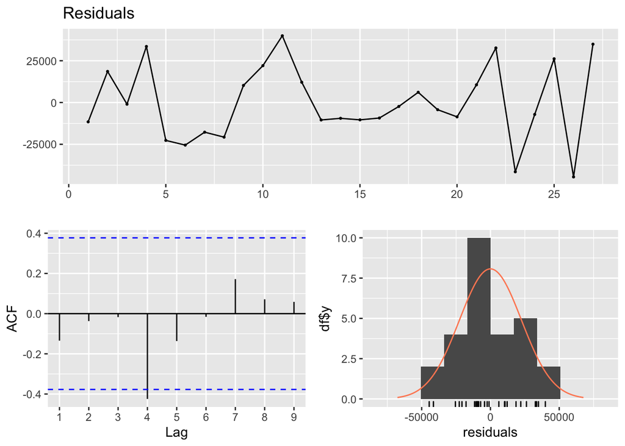

```
##
##  Breusch-Godfrey test for serial correlation of order up to 12
##
## data:  Residuals
## LM test = 20.476, df = 12, p-value = 0.05859
```

```r
checkresiduals(model4)
```

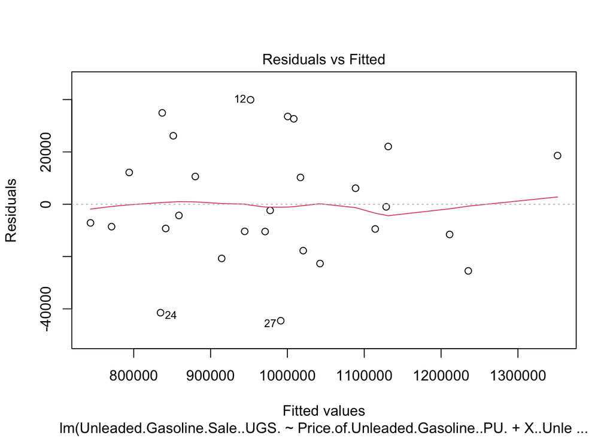

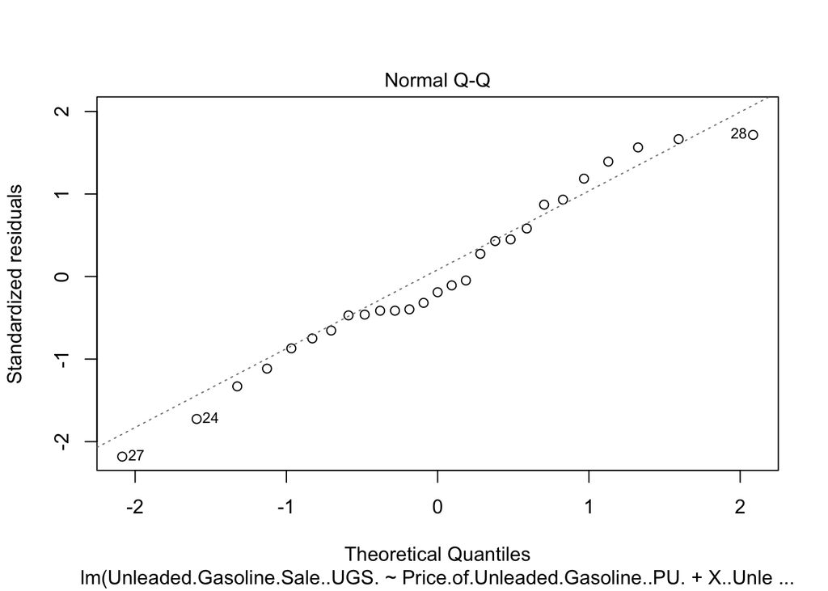

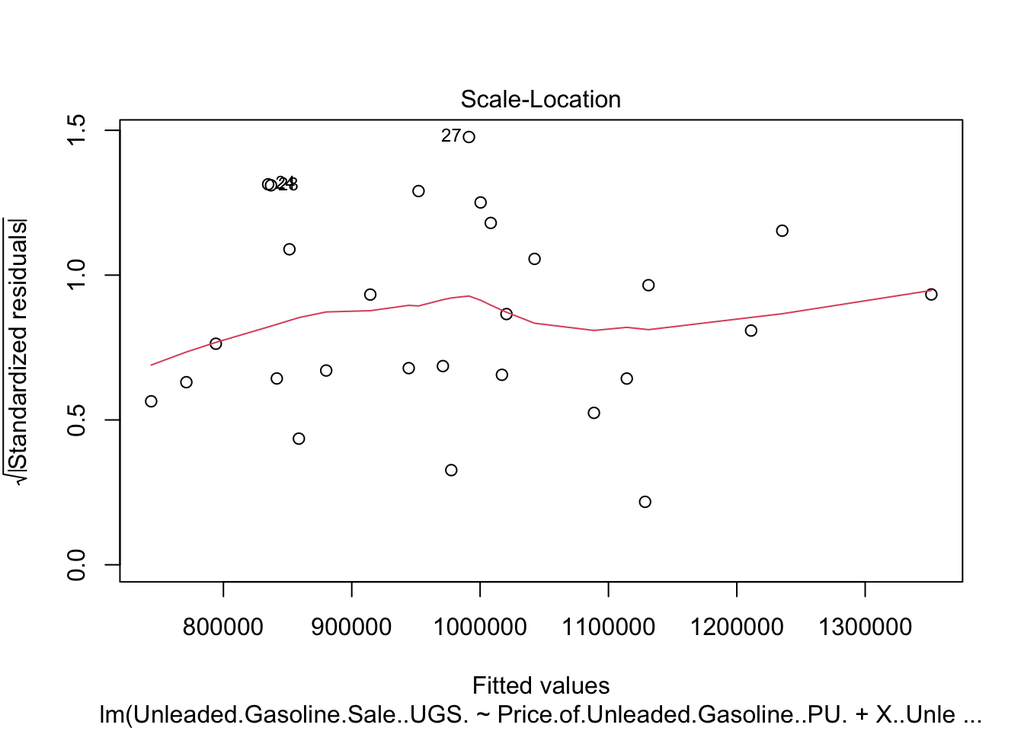

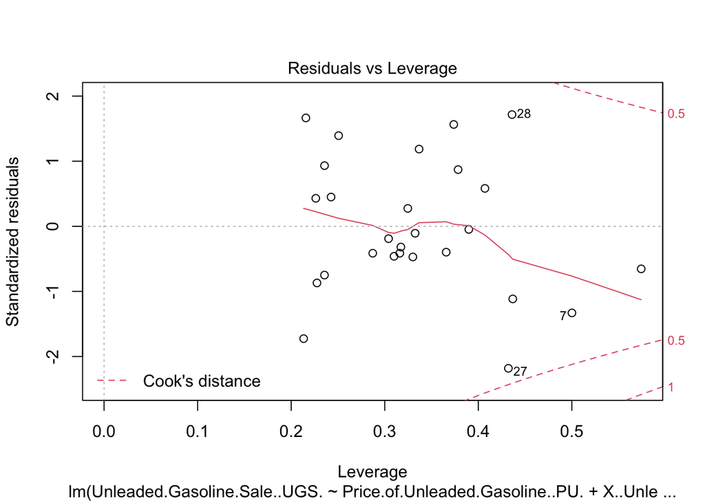

```r
plot(model4)
```

The model seems to be well fit.

##Forecasting

```r
predictions = c()
for(i in 1:4){
  predictions[i] = predict(model4,newdata=data[i+28,])
  if(28 < 32-i){
    data$lag1[i+29] = predictions[i]
  }
}
predictions
```

```
## [1] 662492.3 845565.1 965974.6 788131.3
```

Predictions are present above. The model seems to be well fit.

##Conclusion The model is built through going a trial and error process. The best model is found with respect to the highest adjusted R2 metric. The predictions for the upcoming four periods are present above.